# Assignment Week 3

Ruqia Ali Hassan

2025-03-09

# Loading Libraries

First, all of the necessary libraries for genome analysis are loaded.

```r
suppressPackageStartupMessages({
  library(AnnotationHub)
  library(Rsubread)      # read alignment
  library(rtracklayer)   # read/write genomic file formats
  library(Biostrings)    # handling sequences
  library(Rfastp)        # read QC/trimming
  library(epiwraps)
})
ah <- AnnotationHub()
```

# Downloading the raw data

The raw Drosophila ChIP-seq data is downloaded from ENCODE and saved to a folder called “raw”. The code also checks if the file exists.

```r
options(timeout=3600)
dir.create("raw") #creats a folder named raw
download.file("https://www.encodeproject.org/files/ENCFF127RRR/@@download/ENCFF127RRR.fastq.gz", "raw/ENCFF127RRR.fastq.gz", mode="wb") #dowloades the data in the folder raw
file.exists("raw/ENCFF127RRR.fastq.gz") #checks if file was created
```

# Reads quality control and trimming

`Rfastp` is used to trim and perform quality control on the raw sequencing data. The cleaned reads are saved in the “rfastp.trimmed” folder.

```r
dir.create("rfastp.trimmed") # creates folder named rfastp.trimmed
qc <- Rfastp::rfastp(read1 = "raw/ENCFF127RRR.fastq.gz",
                      outputFastq = "rfastp.trimmed/ENCFF127RRR_trimmed.fastq.gz",
                      thread = 4,
                      overrepresentationAnalysis = TRUE,
                      verbose = TRUE)



file.exists("rfastp.trimmed/ENCFF127RRR_trimmed.fastq.gz_R1.fastq.gz")
```

```
## [1] TRUE
```

# Alignment (using Rsubread)

## Building a genome index for mapping

The reference Drosophila genome is downloaded and indexed using `Rsubread` for read alignment. The genome is saved in FASTA format and a genome index is built.

```r
# we get the genome sequence from AnnotationHub (reference genome for Drosophila (?))
genome <- ah[["AH49674"]]
# we create a new directory that will contain the genome index
dir.create("BDGP6_genome")
# we write the genome sequence in fasta format
export(import.2bit(genome), "BDGP6_genome/genome.fasta.gz", compress=TRUE)
# we build a Rsubread index
Rsubread::buildindex("BDGP6_genome/rsubread", reference="BDGP6_genome/genome.fasta.gz")
```

## Alignment of Reads

The trimmed sequencing reads are aligned to the reference genome using `Rsubread`, and the results are saved as a BAM file in the “aligned” folder.

```r
dir.create("aligned")
align.stats <- Rsubread::align(index = "BDGP6_genome/rsubread",
                               type = "dna",
                               readfile1 = "rfastp.trimmed/ENCFF127RRR_trimmed.fastq.gz_R1.fastq.gz",
                               output_file = "aligned/ENCFF127RRR_aligned.bam",
                               nthreads = 6,
                               sortReadsByCoordinates = TRUE)
```

[output not shown]

[output cut: 25 more lines]

```
##
## //================================   Summary =================================\\
## ||                                                                            ||
## ||                 Total reads : 3816990                                      ||
## ||                      Mapped : 3504769 (91.8%)                              ||
## ||             Uniquely mapped : 3048315                                      ||
## ||               Multi-mapping : 456454                                       ||
## ||                                                                            ||
## ||                    Unmapped : 312221                                       ||
## ||                                                                            ||
## ||                      Indels : 1836                                         ||
## ||                                                                            ||
## ||                Running time : 0.6 minutes                                  ||
## ||                                                                            ||
## \\============================================================================//
```

## Mapped Reads Analysis

Here, the total number of mapped reads and the percentage of reads that align successfully to the genome are calculated.

```r
align.stats
```

```
##                       ENCFF127RRR_aligned.bam
## Total_reads                           3816990
## Mapped_reads                          3504769
## Uniquely_mapped_reads                 3048315
## Multi_mapping_reads                    456454
## Unmapped_reads                         312221
## Indels                                   1836
```

```r
#Total number mapped reads
mapped_reads <- align.stats[2, 1]


#Precentage mappes reads
total_reads <- align.stats[1,1]


percentage_mapped <-round((mapped_reads/total_reads)*100, 2)


#Print
cat("Total number of mapped reads: ", mapped_reads, "\n")
```

```
## Total number of mapped reads:  3504769
```

```r
cat("Total number of reads: ", total_reads, "\n")
```

```
## Total number of reads:  3816990
```

```r
cat("Percentage of mapped reads: ", percentage_mapped, "%\n")
```

```
## Percentage of mapped reads:  91.82 %
```

# Peak calling (using MACS)

`MACSr` is used to identify peaks in the alignment data, indicating regions enriched for the protein CTCF. The number of peaks detected is displayed.

```r
# install MACSr
if(!require("MACSr",quietly=TRUE)) { BiocManager::install("ETHZ-INS/epiwraps", ref="callpeaks")}


library(MACSr)

peaks <- callPeaks(bam="aligned/ENCFF127RRR_aligned.bam")
```

```
## Reading signal and identifying candidate regions...
```

```
## Reading signal coverage...
```

```
## 113697 initial candidate regions
```

```
## Getting strand information
```

```
## 28344 peaks after filtering
```

```
## Reading signal coverage...
```

```
## 59173 initial candidate regions
```

```
## Getting strand information
```

```
## 14373 peaks after filtering
```

```
## Reading signal coverage...
```

```
## 55002 initial candidate regions
```

```
## Getting strand information
```

```
## 13924 peaks after filtering
```

```
## Reading signal coverage...
```

```
## 41053 initial candidate regions
```

```
## Getting strand information
```

```
## 9655 peaks after filtering
```

```
## Identified 66296 candidate regions
```

```
## Computing significance...
```

```
## (In the absence of a control, FDR is unlikely to be calibrated)
```

```
## Reporting 2697 regions, 1172 with FDR<0.05
```

```r
#Number of peaks
num_total_peaks <- length(peaks) #gives number of overal peaks

#Print
cat("Total number of peaks in the alignment data: ", num_total_peaks, "\n")
```

```
## Total number of peaks in the alignment data:  2697
```

## Finding peaks in gene

Here, we find overlapping peaks within gene regions using Drosophila gene annotations from `AnnotationHub` and map the signal around one peak.

```r
head(peaks)
```

```
## GRanges object with 6 ranges and 9 metadata columns:
##       seqnames      ranges strand |  maxCount meanCount    maxPos    maxNeg
##          <Rle>   <IRanges>  <Rle> | <integer> <numeric> <integer> <integer>
##   [1]       2L   1647-1824      * |        31   21.1798         9         7
##   [2]       2L   3148-3174      * |        25   25.0000        11        14
##   [3]       2L   3599-3625      * |        27   27.0000        12        15
##   [4]       2L   4048-4075      * |        21   21.0000        13         8
##   [5]       2L 21389-21528      * |        56   48.9929         9        14
##   [6]       2L 35577-35806      * |        96   76.6739        12         8
##              bg   log10FE    log10p  log10FDR     score
##       <numeric> <integer> <numeric> <numeric> <integer>
##   [1]   6.65598        46      4.99      0.18       299
##   [2]   6.25502        55      8.51      3.69       357
##   [3]   6.13134        59      9.99      5.18       383
##   [4]   6.14767        49      5.95      1.14       318
##   [5]   7.36950        78      6.95      2.14       506
##   [6]   7.02660        99      5.95      1.14       643
##   -------
##   seqinfo: 1870 sequences from an unspecified genome; no seqlengths
```

```r
peaks_gr<-GRanges(peaks)

#Get the annotation
query(ah, "Drosophila") #find fitting gene annotation --> AH119285
```

```
## AnnotationHub with 849 records
## # snapshotDate(): 2024-10-28
## # $dataprovider: UCSC, Ensembl, NCBI,DBCLS, FANTOM5,DLRP,IUPHAR,HPRD,STRING,...
## # $species: Drosophila melanogaster, drosophila melanogaster, Drosophila yak...
## # $rdataclass: GRanges, SQLiteFile, Rle, TwoBitFile, ChainFile, OrgDb, EnsDb...
## # additional mcols(): taxonomyid, genome, description,
## #   coordinate_1_based, maintainer, rdatadateadded, preparerclass, tags,
## #   rdatapath, sourceurl, sourcetype
## # retrieve records with, e.g., 'object[["AH6767"]]'
##
##              title
##   AH6767   | Gap
##   AH6768   | Other RefSeq
##   AH6769   | Genscan Genes
##   AH6770   | D. anan. mRNAs
##   AH6771   | D. mel. Chain
##   ...        ...
##   AH119131 | org.Drosophila_innubila.eg.sqlite
##   AH119169 | org.Drosophila_lebanonensis.eg.sqlite
##   AH119170 | org.Scaptodrosophila_lebanonensis.eg.sqlite
##   AH119195 | org.Drosophila_erecta.eg.sqlite
##   AH119285 | Ensembl 113 EnsDb for Drosophila melanogaster
```

```r
ensdb <- ah[["AH119285"]]
```

```
## loading from cache
```

```
## require("ensembldb")
```

```r
genes <- genes(ensdb) #extracts gene location

#find overlaps
peaksoverlaps <- peaks_gr[queryHits(findOverlaps(peaks_gr, genes))]
#Number of overlaping peaks
num_overlapingpeaks <- length(peaksoverlaps)
cat("Total number of peaks in a gene: ", num_overlapingpeaks, "\n")
```

```
## Total number of peaks in a gene:  1875
```

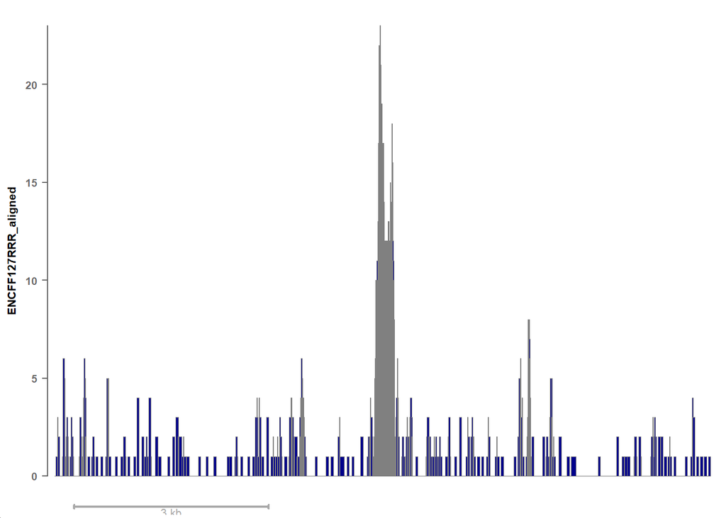

```r
#selecting one peak for plotting
selected_peak <- peaksoverlaps[1] # Select the first peak from the overlapping peaks

#plot the peak
plotSignalTracks(list("aligned/ENCFF127RRR_aligned.bam"), region=selected_peak, extend=5000)
```